# 20_RF_cibersort

Jineta Banerjee

15 November, 2019

```r
## Make colors for plots
fabcolors = RColorBrewer::brewer.pal(n = 11,name = 'RdGy')
col1 = RColorBrewer::brewer.pal(n = 10,name = 'PRGn')
col2 = RColorBrewer::brewer.pal(n = 10,name = 'Spectral')
col3 = RColorBrewer::brewer.pal(n = 10,name = 'BrBG')
col4 = RColorBrewer::brewer.pal(n = 10,name = 'PiYG')
col5 = RColorBrewer::brewer.pal(n = 10,name = 'PuOr')
col6 = RColorBrewer::brewer.pal(n = 10,name = 'RdBu')


allcolors <- c(fabcolors, col1,col2,col3, col4, col5, col6)
allcolors <- list(allcolors)

morecolors1 <- wes_palette("Darjeeling1", n=4, type = "discrete")
morecolors1 <- list(morecolors1)

morecolors2 <- wes_palette("Moonrise2", n=3, type = "discrete")
morecolors2 <- list(morecolors2)

color_list <- c(allcolors, morecolors1, morecolors2)
```

## 0.1 Introduction

- robustness to high dimensionality data
- ability to handle unbalanced classes
- robustness to outliers and non-linear data
- quick training /prediction speeds
- low bias and moderate variance

Our goal is to find important immune celltypes that correlate well with each tumortypes, and thus can be used as a signature. We will then inspect the classifying features (immune subtypes) to find meaningful identifiers that distinguish between two tumortypes.

Tumortypes represented in the data:

- Plexiform Neurofibroma
- MPNST
- Cutaneous Neurofibroma
- Neurofibroma

## 0.2 Partitioning the data into training and testing set:

The dataset was split into 75% training and 25% testing dataset. The function *createDataPartition* is used to create balanced splits of the data. Since the *tumorType* argument to this function is a factor, the random sampling occurs within each class and should preserve the overall class distribution of the data.

```r
#Make the test and training datasets
set.seed(998)  #(if you want to keep the exact same training and testing dataset then uncomment this line)
inTraining <- createDataPartition(as.factor(forest_data$tumorType), p = .75, list = FALSE)

training <- forest_data[ inTraining,]
testing  <- forest_data[-inTraining,]
```

## 0.3 Model training and Crossvalidation :

We first trained an initial model on the training dataset using iterative *mtrys* and 1000 trees. The model was crossvalidated using 5-fold crossvalidation technique.

Below are details of our initial model.

```r
# 10 fold validation control
fitControl <- trainControl(## 5-fold CV
                           method = "repeatedcv",
                           number = 5,
                           ## repeated ten times
                           repeats = 5)

tunegrid <- expand.grid(.mtry=c(1:10))

#Find the classes:
print("Summary of classes in training data")
```

```
## [1] "Summary of classes in training data"
```

```r
summary(training$tumorType)
```

```
##                  Cutaneous Neurofibroma
##                                      25
## Malignant Peripheral Nerve Sheath Tumor
##                                      10
##                            Neurofibroma
##                                       9
##                  Plexiform Neurofibroma
##                                      15
```

```r
## Construct the random forest model called Fit (the code is commented out to facilitate quick rendering of html file by loading the Fit from Synapse)

set.seed(9998)
Fit_init <- train(tumorType ~ .,
             data = training[,c(1:ncol(training))],
             method = "rf",
             ntree= 1000,
             #mtry= c(1:10)
             tuneGrid = tunegrid,
             #classwt =
             proximity=TRUE,
             importance = TRUE,
             trControl = fitControl,
             verbose = TRUE)

print("Check the fit of the initial model")
```

```
## [1] "Check the fit of the initial model"
```

```r
Fit_init
```

```
## Random Forest
##
## 59 samples
## 22 predictors
##  4 classes: 'Cutaneous Neurofibroma', 'Malignant Peripheral Nerve Sheath Tumor', 'Neurofibroma', 'Plexiform Neurofibroma'
##
## No pre-processing
## Resampling: Cross-Validated (5 fold, repeated 5 times)
## Summary of sample sizes: 48, 47, 47, 47, 47, 47, ...
## Resampling results across tuning parameters:
##
##   mtry  Accuracy   Kappa
##    1    0.5351515  0.2529502
##    2    0.6136364  0.4179584
##    3    0.6109091  0.4198216
##    4    0.6312121  0.4546711
##    5    0.6312121  0.4564278
##    6    0.6342424  0.4611354
##    7    0.6342424  0.4646448
##    8    0.6209091  0.4451925
##    9    0.6239394  0.4505106
##   10    0.6272727  0.4545526
##
## Accuracy was used to select the optimal model using the largest value.
## The final value used for the model was mtry = 6.
```

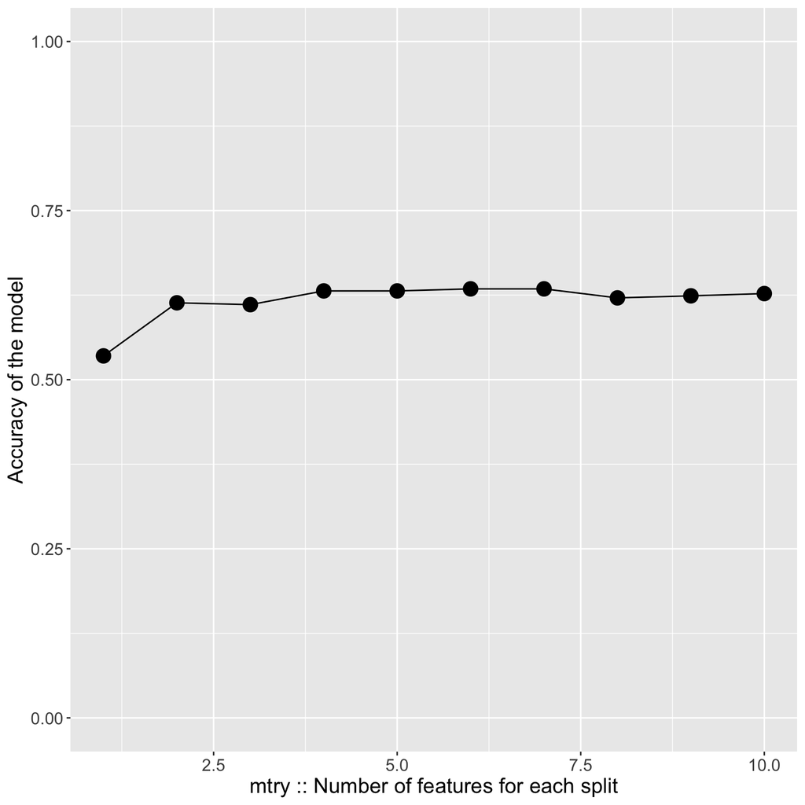

```r
#plot the model
theme_update(text = element_text(size=15))
ggplot(Fit_init$results,  aes(x=mtry, y=Accuracy)) +
  geom_point(aes(size=1)) +
  geom_line() +
  coord_cartesian(ylim = c(0,1)) +
  labs(main="The model", x="mtry :: Number of features for each split", y= "Accuracy of the model") +
  theme(legend.position = "none")
```

```r
print("Check the clustering of the samples according to the initial model")
```

```
## [1] "Check the clustering of the samples according to the initial model"
```

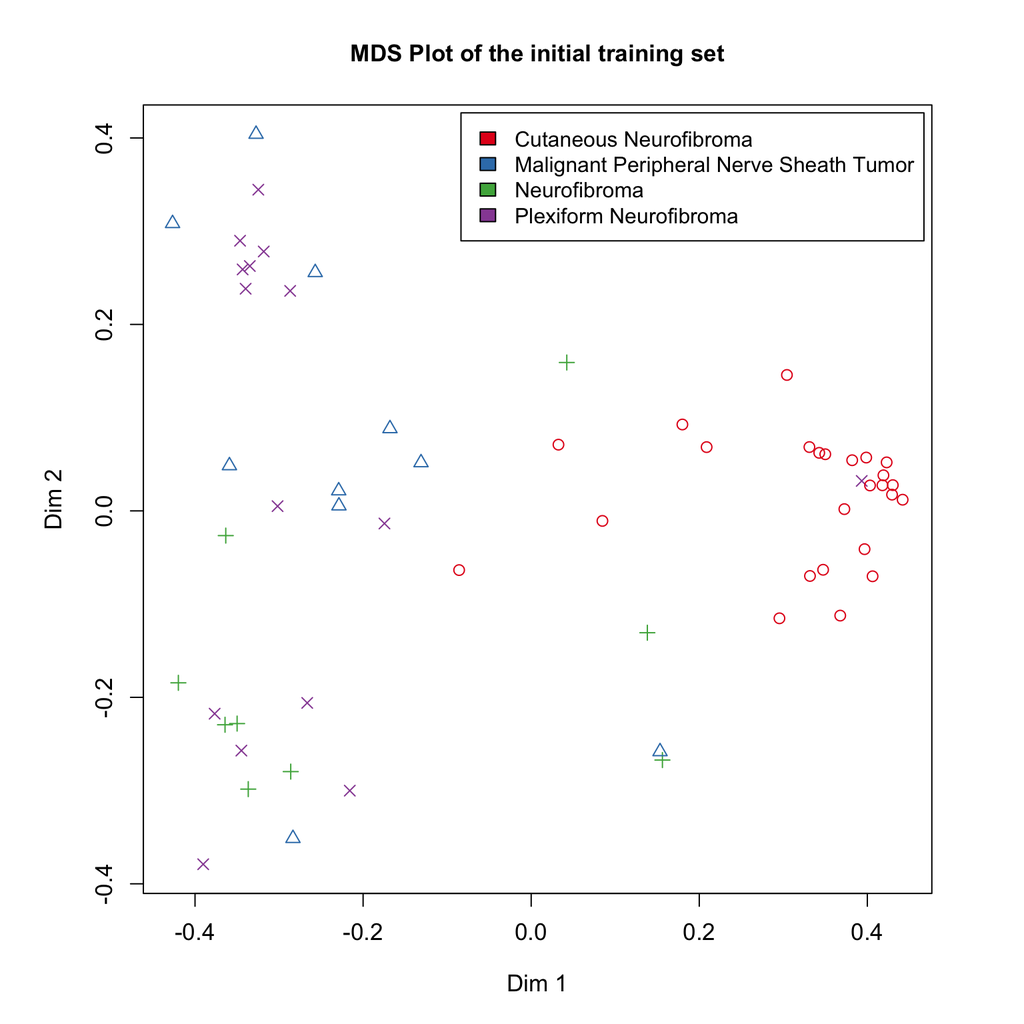

```r
MDSplot(Fit_init$finalModel,
        as.factor(training$tumorType),
        k=2, palette=NULL,
        pch=as.numeric(training$tumorType),
        cex=1.1,
        cex.axis= 1.1,
        cex.lab = 1.1,
        cex.main = 1.1,
        main= "MDS Plot of the initial training set")
legend("topright",
       inset=0.01,
       cex= 1.0,
       legend=levels(training$tumorType),
       fill=brewer.pal(6, "Set1"))
```

```r
#Use model to predict labels of test data
pred <- predict(Fit_init, newdata = testing[,c(1:length(colnames(testing)))])

#store predicted labels in the test dataframe
testing$pred <- pred
```

```r
# Check the accuracy of the model
library(DT)

conf_matrix <- confusionMatrix(data = testing$pred,
                              reference = as.factor(testing$tumorType),
                              mode = "prec_recall")

#conf_matrix

## Make a performance histogram from initial iterations of the forest

perf <- as.data.frame(conf_matrix$byClass)
perf$Class <- rownames(perf)
perf <- perf %>%
  dplyr::select(Class, F1)

# estimate variable importance
importance <- varImp(Fit_init, scale=FALSE)

# Select top important features
list_init <- as.data.frame(importance$importance)


# DT:: datatable(list_init)


#conf_matrix$table
```

## 0.4 Iterating over models

We observed that tuning our model did not significantly improve the performance of the initial model. As a result we tried an ensemble approach where we ran 500 randomized iterations of our forest. In each iteration, a new randomly sampled training set and testing set was generated to generate an independent model. We then plotted the performance of all the 500 independent models to get a distribution of F1 scores for each class. A higher mean F1 score for a class overall would mean a higher classification accuracy for that class.

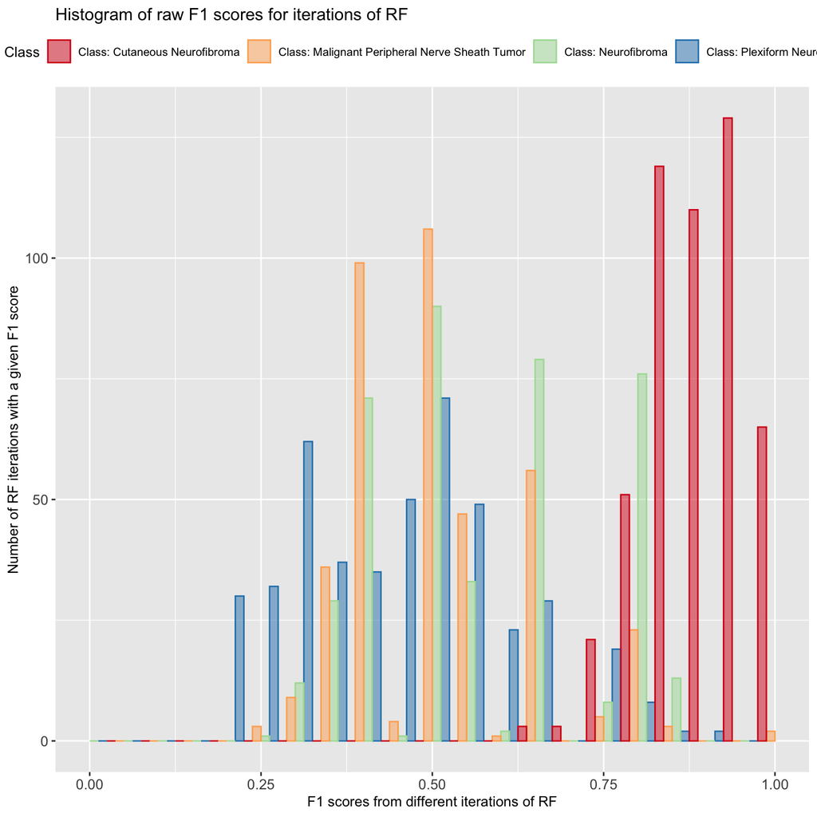

```r
FeatureList <- list()
perf_new <- perf

# Load the Featurelist and perf list stored on synapse
load(synGet("syn21249138")$path)

#The model building code has been commented out below for quick rendering of html

# for (i in 1:500){
#   # make new train-test set
#   inTraining <- createDataPartition(as.factor(forest_data$tumorType), p = .75, list = FALSE)
#   training <- forest_data[ inTraining,]
#   testing  <- forest_data[-inTraining,]
#
#   #make new model
#   Fit_new <- train(tumorType ~ .,
#              data = training[,c(1:ncol(training))],
#              method = "rf",
#              ntree= 1000,
#              #tuneGrid = tunegrid,
#              #classwt =
#              proximity=TRUE,
#              importance = TRUE,
#              trControl = fitControl,
#              verbose = TRUE)
#
#   # predict test set with the model to get F1 scores
#   pred <- predict(Fit_new, newdata = testing[,c(1:length(colnames(testing)))])
#   #store predicted labels in the test dataframe
#   testing$pred <- pred
#
#   #Make confusion matrix
#   conf_matrix <- confusionMatrix(data = testing$pred,
#                               reference = as.factor(testing$tumorType),
#                               mode = "prec_recall")
#
#   ## Store F1 scores from various iterations of the forest
#   df <- as.data.frame(conf_matrix$byClass)
#   perf_new[, glue('Iter{i}')] <- df$F1
#   #perf[, Class] <- rownames(df)
#
#
#   #Store Feature importance for all iterations in a list
#   # estimate variable importance
#   importance <- varImp(Fit_new, scale=FALSE)
#
#   # Select top important features
#   features <- as.data.frame(importance$importance)
#
#   FeatureList[[i]] <- (features)
# }


# Plot histogram of all F1 scores
#Make long df
perf_new$Class <- as.factor(perf_new$Class)
perf_new_long <- gather(perf_new, iteration, All_scores, F1:Iter500, factor_key=TRUE)

par(mfrow=c(2,1))

theme_update(legend.text = element_text(size=8),
      axis.text.x  = element_text(size=10),
      axis.text.y = element_text(size=10),
      text = element_text(size=10))

ggplot(perf_new_long, aes(x=All_scores, fill=Class, color= Class)) +
  geom_histogram( binwidth=0.05, alpha=0.5, position="dodge") +
  theme(legend.position="top") +
  scale_color_brewer(palette="Spectral")+
  scale_fill_brewer(palette="Spectral") +
  labs(title="Histogram of raw F1 scores for iterations of RF",x="F1 scores from different iterations of RF", y = "Number of RF iterations with a given F1 score") +
  xlim(0, 1)
```

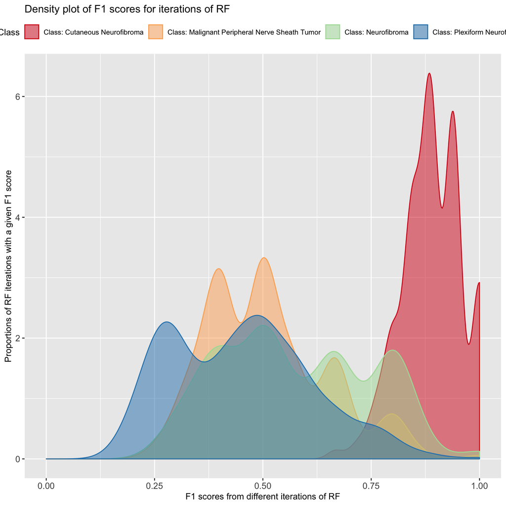

```r
ggplot(perf_new_long, aes(x=All_scores, fill=Class, color=Class)) +
  #geom_histogram( binwidth=0.05, alpha=0.5, position="dodge") +
  geom_density(alpha=0.5) +
  theme(legend.position="top") +
  #scale_color_manual(values=allcolors[[1]][12:18])
  scale_color_brewer(palette="Spectral")+
  scale_fill_brewer(palette="Spectral") +
  labs(title="Density plot of F1 scores for iterations of RF",x="F1 scores from different iterations of RF", y = "Proportions of RF iterations with a given F1 score") +
  xlim (0,1)
```

## 0.5 Feature Importance evaluation

From our independently generated 500 models, we saved the importance scores of all the features for each of the classes. We then plotted the distribution of importance scores of each of the features to estimate the mean importance of a particular feature for that class. The density plots of importance scores of all the features (immune cell types) for a specific class (tumor type) are show below:

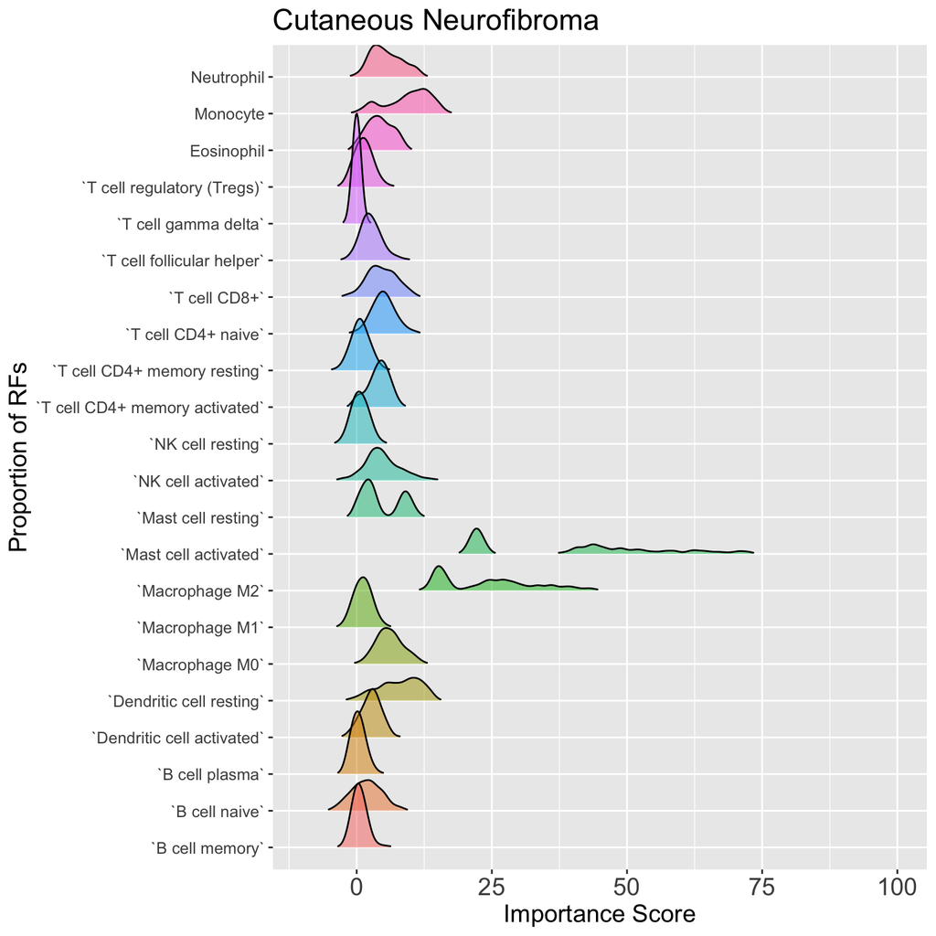

```r
# Filter Importance scores of features for each Class
features_cNF <- as.data.frame(sapply(FeatureList, `[[`, 1))
features_MPNST <- as.data.frame(sapply(FeatureList, `[[`, 2))
features_NF <- as.data.frame(sapply(FeatureList, `[[`, 3))
features_pNF <- as.data.frame(sapply(FeatureList, `[[`, 4))


# Plot the distribution of importance scores of features
ridgeplot_classes <- function(featurelist, dataframe, class){
  #add Class column
  dataframe$Celltype <- rownames(featurelist[[1]])
  #make long df
  dataframe_long <- gather(dataframe, iteration, All_scores, V1:V500, factor_key=TRUE)
  #make ridgeplot
  theme_update(legend.text = element_text(size=8),
      axis.text.x  = element_text(size=15),
      axis.text.y = element_text(size=10),
      text = element_text(size=15))
  ggplot(dataframe_long, aes(x=All_scores, y=Celltype, fill=Celltype)) +
  geom_density_ridges(scale = 3, rel_min_height = 0.01, alpha= 0.5)  +
  theme(legend.position="none") +
  scale_color_manual(values=color_list[[1]]) +
  labs(title= glue('{class}'),x="Importance Score", y = "Proportion of RFs") +
  xlim(-10,100)
}

ridgeplot_classes(FeatureList, features_cNF, "Cutaneous Neurofibroma")
```

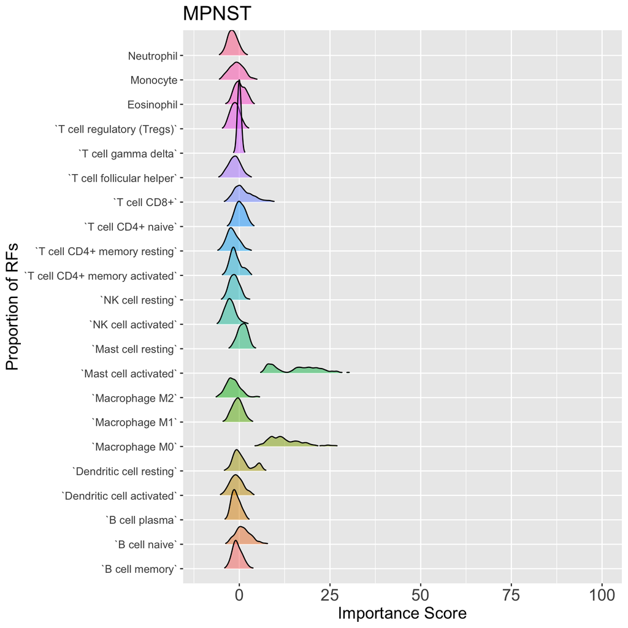

```r
ridgeplot_classes(FeatureList, features_MPNST, "MPNST")
```

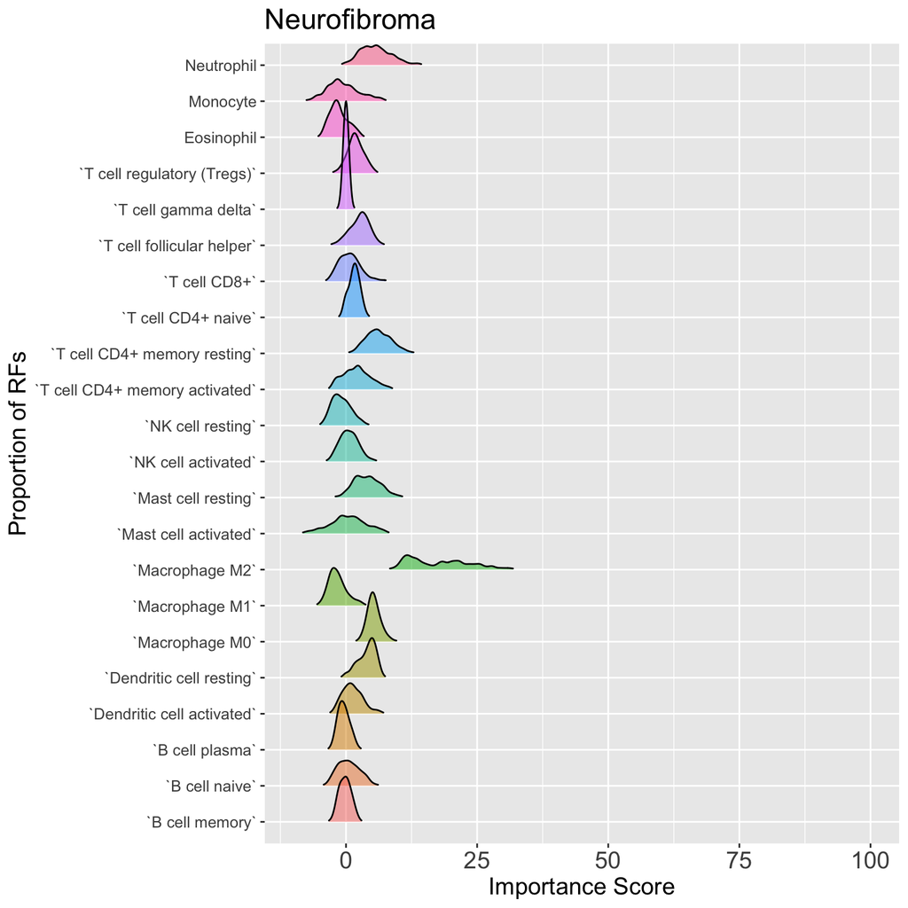

```r
ridgeplot_classes(FeatureList, features_NF, "Neurofibroma")
```

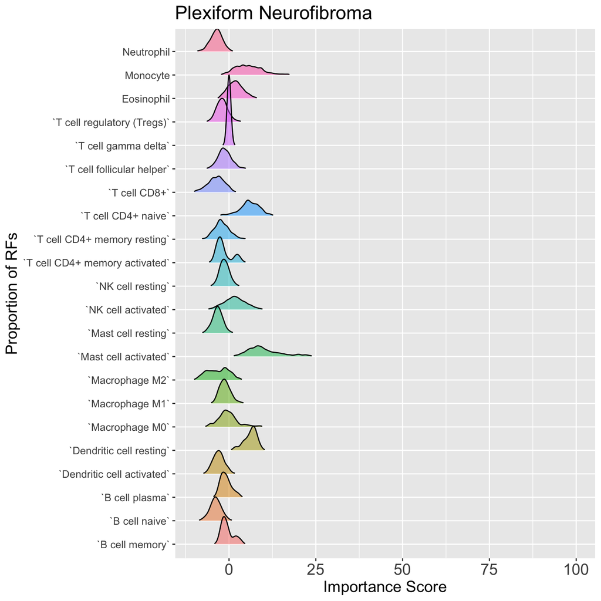

```r
ridgeplot_classes(FeatureList, features_pNF, "Plexiform Neurofibroma")
```

```r
#save(FeatureList, perf_new, file = "RF_cibersort.RData")
```